# Tutorial 1a - INLA basics

Spatial and Spatio-Temporal Bayesian Models with `R-INLA`

In this practical we will use simulated data to get familiar with the basic `R-INLA` functions. Moreover, we will see how to change the prior distributions.

# Data simulation

The data are simulated from the following model
$$y_i \sim \text{Normal}(\eta_i, \sigma=0.1) \qquad i=1,\ldots,n=100$$
with
$$\eta_i = \beta_0+ \beta_1 x_i$$
where $\beta_0=2$, $\beta_1=0.5$ and the values of the covariate $\boldsymbol{x}$ are generated from an Uniform(0,1) distribution. The simulated response and covariate data are then saved in a `data.frame` object.

```r
set.seed(1234) #set the seed
n = 100
sigma = 0.1
beta.0 =  2
beta.1 = 0.5
x = runif(n)
eta = beta.0 +  beta.1*x
y = rnorm(n,eta,sigma)
#plot(x,y) #plot the data
my.data = data.frame(y=y,x=x)
```

# Model estimation and output exploration

We use `R-INLA` to estimate the parameters of the given model where $\boldsymbol \theta=\{\beta_0,\beta_1\}$ and $\boldsymbol\psi=\{1/\sigma^2\}$. In particular:

1. we load the `R-INLA` library and define the `formula` (it includes only fixed effects)

(remember to install it if you have not done it before using `install.packages("INLA", repos="http://www.math.ntnu.no/inla/R/stable")`)

```r
library(INLA)
formula = y ~ 1 + x
```

2. we call the `inla` function for estimation

```r
output = inla(formula, family="gaussian", data=my.data)
```

```r
#plot(output)
summary(output)
```

```
##
## Call:
##    "inla(formula = formula, family = \"gaussian\", data = my.data)"
## Time used:
##     Pre = 0.584, Running = 0.0631, Post = 0.0334, Total = 0.681
## Fixed effects:
##              mean    sd 0.025quant 0.5quant 0.975quant  mode kld
## (Intercept) 2.010 0.018      1.975    2.010      2.045 2.010   0
## x           0.496 0.034      0.428    0.496      0.563 0.496   0
##
## Model hyperparameters:
##                                           mean    sd 0.025quant 0.5quant
## Precision for the Gaussian observations 111.88 15.83      83.02   111.13
##                                         0.975quant   mode
## Precision for the Gaussian observations     144.99 109.64
##
## Expected number of effective parameters(stdev): 2.07(0.01)
## Number of equivalent replicates : 48.37
##
## Marginal log-Likelihood:  77.14
```

4. If we are interested in extracting the marginal posterior distribution of $\beta_0$ and $\beta_1$ we use the following code:

```r
names(output$marginals.fixed) #check the fixed effect names
```

```
## [1] "(Intercept)" "x"
```

```r
class(output$marginals.fixed) #NOTE: it is a list
```

```
## [1] "list"
```

```r
post.beta0 = output$marginals.fixed[[1]]
post.beta1 = output$marginals.fixed$x
```

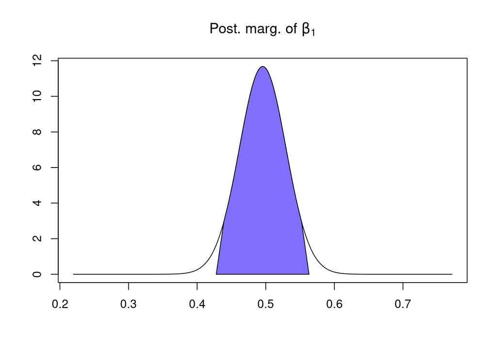

```r
####beta1
plot(inla.smarginal(post.beta1),type="l",xlab="",ylab="",
     main=expression(paste("Post. marg. of ", beta[1])))
hpd.beta1 = inla.hpdmarginal(p=0.95,post.beta1)
polygon(c(hpd.beta1[1],post.beta1[post.beta1[,1] >= hpd.beta1[1] & post.beta1[,1] <= hpd.beta1[2],1], hpd.beta1[2]),
         c(0,post.beta1[post.beta1[,1] >= hpd.beta1[1] & post.beta1[,1] <= hpd.beta1[2] ,2],0),
         col = "slateblue1", border = 1)
```

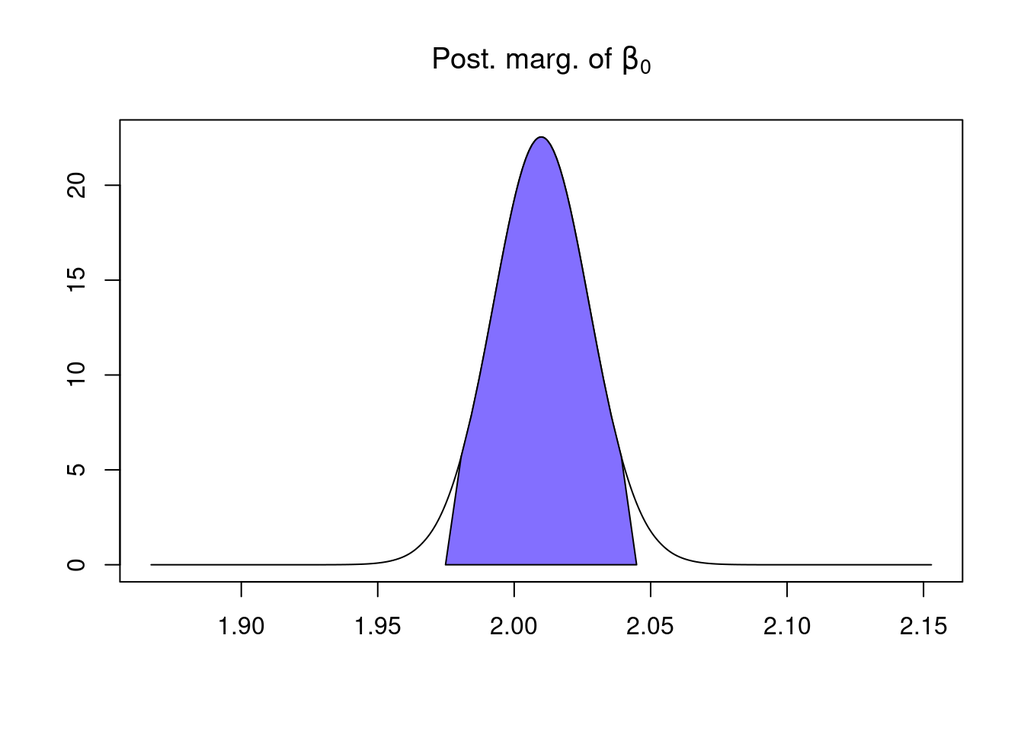

```r
####Intercept
plot(inla.smarginal(post.beta0),type="l",xlab="",ylab="",
     main=expression(paste("Post. marg. of ", beta[0])))
hpd.beta0 = inla.hpdmarginal(p=0.95,post.beta0)
polygon(c(hpd.beta0[1],post.beta0[post.beta0[,1] >= hpd.beta0[1] & post.beta0[,1] <= hpd.beta0[2],1], hpd.beta0[2]),
         c(0,post.beta0[post.beta0[,1] >= hpd.beta0[1] & post.beta0[,1] <= hpd.beta0[2] ,2],0),
         col = "slateblue1", border = 1)
```

5. Now we want to plot the marginal posterior distribution of the measurement error standard deviation $\sigma$ starting from the marginal posterior distribution of the precision for the Gaussian observations. The transformation is done through the `inla.tmarginal` function as follows:

```r
names(output$marginals.hyperpar) #check the hyperparameter name
```

```
## [1] "Precision for the Gaussian observations"
```

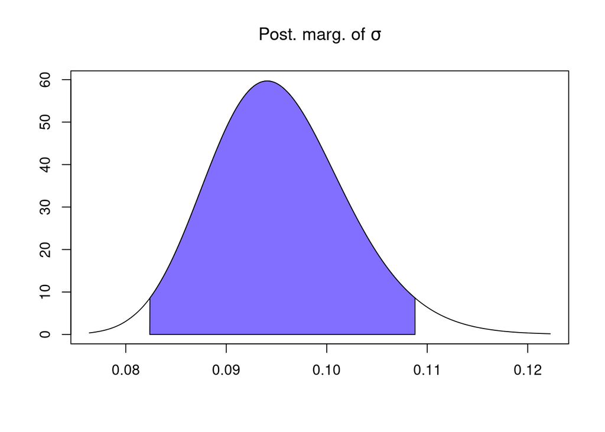

```r
post.sigma = inla.tmarginal(function(x) sqrt(1/x),
        output$marginals.hyperpar[[1]])
#We use [[1]] instead of the long name

plot(inla.smarginal(post.sigma),type="l",xlab="",
ylab="",main=expression(paste("Post. marg. of ", sigma)))
hpd.sigma = inla.hpdmarginal(p=0.95,post.sigma)
polygon(c(hpd.sigma[1],post.sigma[post.sigma[,1] >= hpd.sigma[1] & post.sigma[,1] <= hpd.sigma[2],1], hpd.sigma[2]),
         c(0,post.sigma[post.sigma[,1] >= hpd.sigma[1] & post.sigma[,1] <= hpd.sigma[2] ,2],0),
         col = "slateblue1", border = 1)
```

Finally we can obtain some summary statistics about the distribution using the `inla.zmarginal` function:

```r
inla.zmarginal(post.sigma)
```

```
## Mean            0.0952545
## Stdev           0.00677306
## Quantile  0.025 0.0830857
## Quantile  0.25  0.0904872
## Quantile  0.5   0.0948478
## Quantile  0.75  0.0995692
## Quantile  0.975 0.109669
```

# Change the priors

## Fixed effects

The default prior adopted by `R-INLA` for the regression parameters $\beta_0$ and $\beta_1$ is the vague distribution $\text{Normal}(0,10^6)$ (see also Section 5.1 and 5.1.2 of the INLA book). The option `control.fixed` of the `inla` function can be used for changing these priors. For example if we want to specifiy $\beta_0\sim\text{Normal}(0,10^4)$ and $\beta_1\sim\text{Normal}(0,1)$ we will use the following code:

```r
output2 = inla(formula, family="gaussian", data=my.data,
               control.fixed=list(mean=0,prec=1,
                                  mean.intercept=0,prec.intercept=0.0001))
```

where `mean` and `prec` represent the mean and precision of the regression parameters (excluding the intercept, whose parameters can be accessed through `mean.intercept` and `prec.intercept`).

[output not shown]

## Outcome precision $(1/\sigma^2)$

The default prior adopted by `R-INLA` for the response precision $\tau=1/\sigma^2$ is a noninformative logGamma prior defined on the logarithm of the precision (internal scale). the default prior distribution is
$$\log(\tau)=\log(1/\sigma^2)\sim \text{logGamma}(1,5e-05)$$
This is equivalnt to assume a Gamma prior on the precision, ie $\tau\sim \text{Gamma}(1, 0.00005)$ (see Section 5.1 and 5.1.2 of the INLA book).
It is possible to change this prior using the `control.family` option of the `inla` function. For example if we want to specify a standard Normal(0,1) prior on the logarithm of the precision we will type:

```r
output3 = inla(formula, family="gaussian", data=my.data,
               control.family=list(hyper=list(
                                    prec=list(prior="gaussian",param=c(0,1))))
               )
```

Instead if we want to assume for $\tau$ a Gamma-prior with parameters (1, 0.01) we will type:

```r
output4 = inla(formula, family="gaussian", data=my.data,
               control.family=list(hyper=list(
                                  prec=list(prior="loggamma",param=c(1,0.01))))
               )
```

The default and two alternative posterior distributions are compared below:

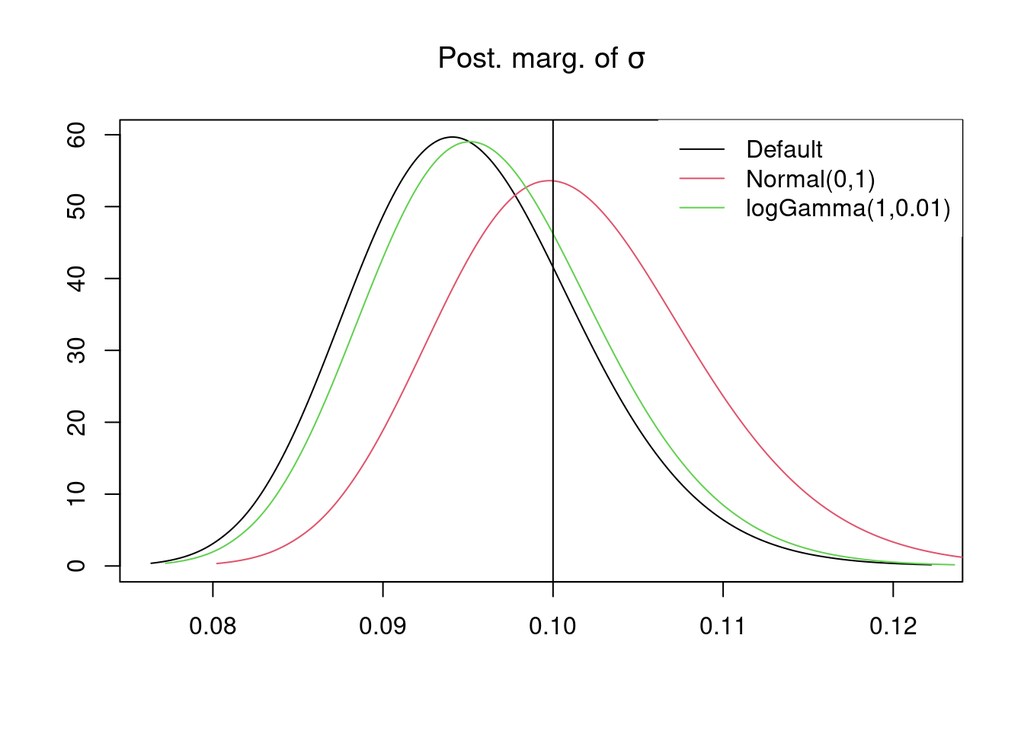

```r
post.sigma3 = inla.tmarginal(function(x) sqrt(1/x),
        output3$marginals.hyperpar[[1]])
post.sigma4 = inla.tmarginal(function(x) sqrt(1/x),
      output4$marginals.hyperpar[[1]])

plot(inla.smarginal(post.sigma),type="l",xlab="",
ylab="",main=expression(paste("Post. marg. of ", sigma)))
lines(inla.smarginal(post.sigma3),col=2)
lines(inla.smarginal(post.sigma4),col=3)
abline(v=sigma)
legend("topright",col=c(1,2,3),lty=c(1,1,1),
       legend=c("Default","Normal(0,1)","logGamma(1,0.01)"),box.lty=0)
```